# Introduction to bartcs

Yeonghoon Yoo

```r
set.seed(42)
library(bartcs)
```

The **bartcs** package finds confounders and treatment effect with Bayesian Additive Regression Trees (BART).

## Tutorial with IHDP dataset

This tutorial will use The Infant Health and Development Program (IHDP) dataset. IHDP is a randomized experiment from 1985 to 1988 which studied the effect of home visits on cognitive test scores for infants. Our version is a synthetic dataset generated by Louizos et al. (2017) which provides true values to compare with. The dataset consists of 6 continuous and 19 binary covariates with simulated outcome which is a cognitive test score.

```r
data(ihdp, package = "bartcs")

fit <- single_bart(
  Y               = ihdp$y_factual,
  trt             = ihdp$treatment,
  X               = ihdp[, 6:30],
  num_tree        = 10,
  num_chain       = 4,
  num_post_sample = 100,
  num_burn_in     = 100,
  verbose         = FALSE
)
fit
```

```
#> `bartcs` fit by `single_bart()`
#>
#>          mean     2.5%    97.5%
#> SATE 3.989180 3.757940 4.194852
#> Y1   6.414511 6.209326 6.594922
#> Y0   2.425331 2.352195 2.512516
```

You can get mean and 95% credible interval of average treatment effect (ATE) and possible outcome Y1 and Y0.

```r
SATE <- mean(ihdp$mu1 - ihdp$mu0)
SATE
```

```
#> [1] 4.016067
```

```r
mu1 <- mean(ihdp$mu1)
mu1
```

```
#> [1] 6.44858
```

```r
mu0 <- mean(ihdp$mu0)
mu0
```

```
#> [1] 2.432513
```

```r
mse <- mean((unlist(fit$mcmc_list[, "SATE"]) - SATE)^2)
mse
```

```
#> [1] 0.01311197
```

True values of ATE, mu1 and mu0 all lies in 95% credible interval. Also, MSE between predicted and true values is 0.013.

## Result

Both `separate_bart()` and `single_bart()` fits multiple MCMC chains. `summary()` provides result for each and aggregated chain.

```r
summary(fit)
```

```
#> `bartcs` fit by `single_bart()`
#>
#> Treatment Value
#>   Treated group    :      1
#>   Control group    :      0
#>
#> Tree Parameters
#>   Number of Tree   :     10      Value  of alpha    :   0.95
#>   Prob.  of Grow   :   0.28      Value  of beta     :      2
#>   Prob.  of Prune  :   0.28      Value  of nu       :      3
#>   Prob.  of Change :   0.44      Value  of q        :   0.95
#>
#> Chain Parameters
#>   Number of Chains :      4      Number of burn-in  :    100
#>   Number of Iter   :    200      Number of thinning :      1
#>   Number of Sample :    100
#>
#> Outcome
#>  estimand chain     2.5%       1Q     mean   median       3Q    97.5%
#>      SATE     1 3.773543 3.911107 3.972227 3.970111 4.056683 4.151239
#>      SATE     2 3.772706 3.941568 3.999966 4.008911 4.055016 4.193598
#>      SATE     3 3.741889 3.859122 3.943162 3.959975 4.021592 4.118731
#>      SATE     4 3.819920 3.971550 4.041364 4.045832 4.111067 4.252098
#>      SATE   agg 3.757940 3.914043 3.989180 3.990748 4.061248 4.194852
#>        Y1     1 6.215452 6.328724 6.396984 6.404919 6.460931 6.543268
#>        Y1     2 6.261225 6.359134 6.426559 6.434194 6.486718 6.590550
#>        Y1     3 6.184771 6.320276 6.377308 6.382648 6.450492 6.545511
#>        Y1     4 6.245013 6.393345 6.457192 6.465348 6.513756 6.672324
#>        Y1   agg 6.209326 6.347214 6.414511 6.423418 6.480329 6.594922
#>        Y0     1 2.342513 2.399295 2.424757 2.423876 2.451448 2.506433
#>        Y0     2 2.355629 2.398670 2.426593 2.426521 2.448976 2.495499
#>        Y0     3 2.357711 2.401557 2.434146 2.431961 2.460607 2.517344
#>        Y0     4 2.346422 2.389331 2.415827 2.412804 2.441819 2.511036
#>        Y0   agg 2.352195 2.397022 2.425331 2.424030 2.450444 2.512516
```

## Data Visualization

You can get posterior inclusion probability for each variables.

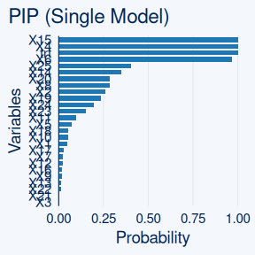

```r
plot(fit, method = "pip")
```

Since `inclusion_plot()` is a wrapper function of `ggcharts::bar_chart()`, you can use its arguments for better plot.

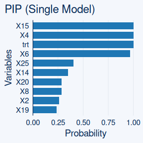

```r
plot(fit, method = "pip", top_n = 10)
```

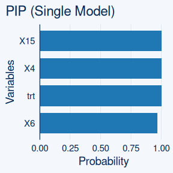

```r
plot(fit, method = "pip", threshold = 0.5)
```

With `trace_plot()`, you can visually check trace of effects or other parameters.

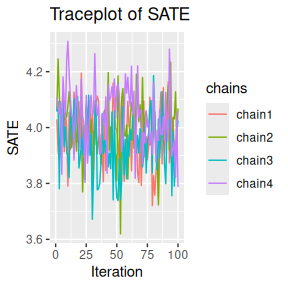

```r
plot(fit, method = "trace")
```

## Connection to coda Package

You can also use functions from `coda` package for components of `bartcs` object. Components with `mcmc_` prefix are `mcmc.list` object from `coda` package.

```r
coda::gelman.diag(fit$mcmc_list[, "SATE"])
```

```
#> Potential scale reduction factors:
#>
#>      Point est. Upper C.I.
#> [1,]        1.1       1.28
```

## Multi-threading

```r
count_omp_thread()
```

```
#> [1] 12
```

Check whether OpenMP is supported. You need more than 1 thread for multi-threading. Due to overhead of multi-threading, using parallelization will **NOT** be effective with small and moderate size datasets.

For comparison purpose, I will create dataset with 40,000 rows by bootstrapping from IHDP dataset. Then, for fast computation, I will fit the model with most parameters set to 1.

```r
idx  <- sample(nrow(ihdp), 4e4, TRUE)
ihdp <- ihdp[idx, ]

microbenchmark::microbenchmark(
  simple = single_bart(
    Y               = ihdp$y_factual,
    trt             = ihdp$treatment,
    X               = ihdp[, 6:30],
    num_tree        = 1,
    num_chain       = 1,
    num_post_sample = 10,
    num_burn_in     = 0,
    verbose         = FALSE,
    parallel        = FALSE
  ),
  parallel = single_bart(
    Y               = ihdp$y_factual,
    trt             = ihdp$treatment,
    X               = ihdp[, 6:30],
    num_tree        = 1,
    num_chain       = 1,
    num_post_sample = 10,
    num_burn_in     = 0,
    verbose         = FALSE,
    parallel        = TRUE
  ),
  times = 50
)
```

```
#> Unit: milliseconds
#>      expr       min       lq     mean   median       uq      max neval
#>    simple 101.33121 112.9739 128.6427 122.1777 136.3544 255.4939    50
#>  parallel  86.46245 106.5992 140.6403 123.6977 165.6306 282.6519    50
```

## References

Louizos, Christos, Uri Shalit, Joris M Mooij, David Sontag, Richard Zemel, and Max Welling. 2017. “Causal Effect Inference with Deep Latent-Variable Models.” *Advances in Neural Information Processing Systems* 30. https://doi.org/10.48550/arXiv.1705.08821.